# CLK refactor and test of robustness

## Introduction

CLK-dependent exon recognition and conjoined gene formation revealed with a novel small molecule inhibitor

[CLK](https://www.ncbi.nlm.nih.gov/gene?Db=gene&Cmd=ShowDetailView&TermToSearch=1195) encodes a member of the CDC2-like (or LAMMER) family of dual specificity protein kinases. In the cell nucleus, the encoded protein phosphorylates serine/arginine-rich proteins involved in pre-mRNA processing, releasing them into the nucleoplasm. The choice of splice sites during pre-mRNA processing may be regulated by the concentration of transacting factors, including serine/arginine-rich proteins. Therefore, the encoded protein may play an indirect role in governing splice site selection.

The authors describe a new compound, T3, a CLK small molecule inhibitor which shows superior potentcy and selectivity than the current standard, KH-CB19.

Of particular interest in the formation of conjoined genes (CG) when CLK is inhibited.

### Sequencing

```r
library(knitr)
library(rmarkdown)
library(ggplot2)
library(stringr)
library(biomaRt)
library(Gviz)
library(org.Hs.eg.db)
library(TxDb.Hsapiens.UCSC.hg38.knownGene)
library(dplyr)
metadata<-read.csv("metadata/metadata.csv")

# for my notes: Oo1Zafe3Qox3
```

### Breakdowns

#### By platform

```r
metadata %>% group_by(Platform) %>% summarize(samples=n(),median_reads=median(spots))
```

| Platform | samples | median_reads |
| --- | --- | --- |
| ILLUMINA | 109 | 795864 |
| PACBIO_SMRT | 60 | 81741 |

#### By cell line

HCT116 is a human colorectal carcinoma (i.e. malignant or “transformed”) cell line. 184-hTERT-L2 cell line is derived from human mammary epithelial cells immortalized by transduction with hTERT.

```r
metadata$cell_line<-as.vector(str_extract_all(metadata$SampleName,'(HCT116|184-hTert)',simplify=TRUE))
metadata %>% group_by(cell_line) %>% summarize(samples=n()) %>% arrange(-samples)
```

| cell_line | samples |
| --- | --- |
| HCT116 | 161 |
| 184-hTert | 8 |

#### By treatment

Various silencing transfections were tested on CLK itself, splicing factors such as U2AF2 and SRSF9, TIA1 and CPEB RNA-binding proteins siCLK, siCPEB ,siDAZA, siHNRNPH, siKHDRBS1, siLIN28A, siELAVL1, siHNRNPC, siHNRNPF, siU2AF2, siTIA, siSRSF, siSRRM, siSFPQ, siSAMD4B, RNA recognition motif (RRMs) and splicing enhancers are also tested.

```r
metadata %>% group_by(SampleName) %>% summarize(samples=n()) %>% arrange(-samples)
```

| SampleName | samples |
| --- | --- |
| 0.5 uM T3 treated HCT116 | 24 |
| 5 uM T3 treated HCT116 | 24 |
| Untreated HCT116 | 24 |
| 1.0 uM T3 treated HCT116 | 4 |
| 0.05 uM T3 treated HCT116 | 2 |
| 0.1 uM T3 treated HCT116 | 2 |
| 0.5 uM T3 treated 184-hTert | 2 |
| 1.0 uM T3 treated 184-hTert | 2 |
| 10 uM T3 treated HCT116 | 2 |
| 5.0 uM T3 treated 184-hTert | 2 |

[output cut: 80 more lines]

### Alignment and rMATS-ISO

Alignment was performed with STAR against hg38 using GTEX pipeline settings. The alignments themselves were run on the Truwl.com platform.

```
STAR --runMode alignReads \
     --outSAMtype BAM SortedByCoordinate \
     --limitBAMsortRAM ${bytes} \
     --readFilesCommand zcat \
     --outFilterType BySJout   --outFilterMultimapNmax 20 \
     --outFilterMismatchNmax 999   --alignIntronMin 25  \
     --alignIntronMax 1000000   --alignMatesGapMax 1000000 \
     --alignSJoverhangMin 8   --alignSJDBoverhangMin 5 \
     --sjdbGTFfile GRCh38_star/genes.gtf \
     --genomeDir GRCh38_star \
     --runThreadN ${cpus} \
     --outFileNamePrefix ${sample}.  \
     --readFilesIn  ${sample}_1.fastq.gz ${sample}_2.fastq.gz
```

RMATS-ISO was run using the gencode.v28.annotation.gtf, roughly equivalent to the Ensembl gtf.

### RMATS-EM output

The following columns are returned from rMATS-EM:

```
 [1] "ASM_name"                        "total_isoforms"                  "total_exons"                     "total_read_count_group_1"        "total_read_count_group_2"
 [6] "p_value"                         "test_statistic"                  "isoform_inclusion_group_1"       "isoform_inclusion_group_2"       "isoform_inclusion_constrained"
[11] "variance_group_1"                "variance_group_2"                "variance_constrained"            "dirichlet_parameter_group_1"     "dirichlet_parameter_group_2"
[16] "dirichlet_parameter_constrained" "paired_isoform_pvalues"          "isoform_index"                   "merge_info"
```

### Dose dependent splicing patterns of T3 in HCT116

```r
pthresh<-0.01
doses<-c('0.05','0.5','1.0','5.0')
control<-"untreated"
```

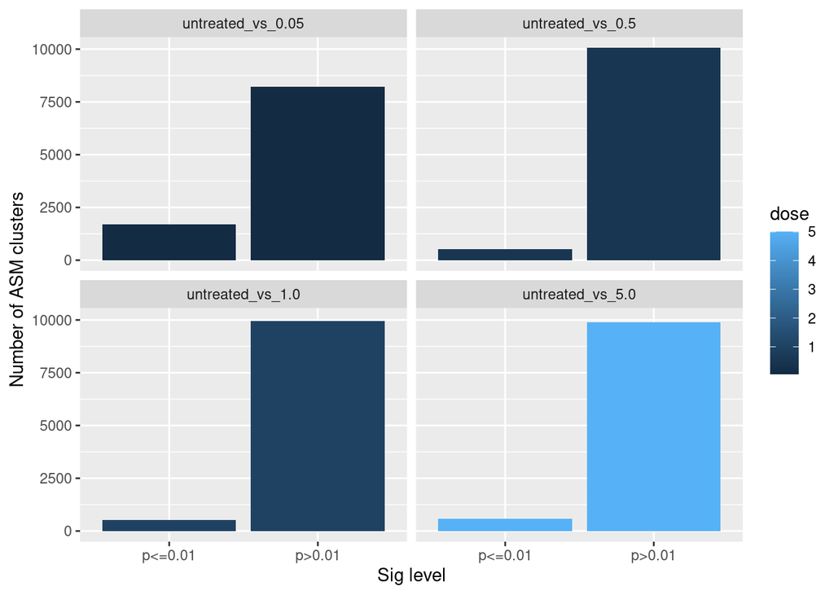

```r
em_all<-NULL
for(dose in doses){
  em<-read.table(paste0("results/iso_",control,'_vs_',dose,'/EM_out/EM.out'),comment.char = '',strip.white = TRUE, header=TRUE)
  em$dose<-as.numeric(dose)
  em$dosestr<-paste0(control,'_vs_',dose)
  if(!is.null(em_all)){
    em_all<-rbind(em_all,em)
  }else{
    em_all<-em
  }
}

#set p_value of 0 to a token dummy minimum, display only highly significant assemblies
#ggplot(em_all %>% filter(!is.na(p_value)) %>% filter(p_value<=0.01) %>% rowwise() %>% dplyr::mutate(p_value = max(p_value,1e-16)),aes(-log(p_value)))+geom_histogram(binwidth=1)+facet_wrap(.~dose)
ggplot(em_all %>% dplyr::filter(!is.na(p_value)) %>% rowwise() %>% mutate(sig=ifelse(p_value<=pthresh,paste0("p<=",pthresh),paste0("p>",pthresh))),aes(sig,fill=dose))+geom_bar(stat="count")+ylab("Number of ASM clusters")+xlab("Sig level")+facet_wrap(.~dosestr)
```

```r
em_all %>% dplyr::filter(!is.na(p_value)) %>% rowwise() %>% mutate(sig=p_value<=pthresh) %>% group_by(dose,sig) %>% summarize(cnt=n()) %>% reshape2::acast(dose~sig) -> sig_table
dimnames(sig_table)[[2]]<-c(paste0("p>",pthresh),paste0("p<=",pthresh))
sig_table<-cbind(sig_table,total=rowSums(sig_table))
sig_table<-cbind(sig_table,sig_frac=round(sig_table[,2]/sig_table[,3],2))
fold_change<-c(0,sapply(1:(nrow(sig_table)-1),function(x){(sig_table[x+1,2]/sig_table[x+1,3])/(sig_table[x,2]/sig_table[x,3])}))
sig_table<-cbind(sig_table,fold_change=fold_change)
knitr::kable(sig_table)
```

|  | p>0.01 | p<=0.01 | total | sig_frac | fold_change |
| --- | --- | --- | --- | --- | --- |
| 0.05 | 8228 | 1698 | 9926 | 0.17 | 0.0000000 |
| 0.5 | 10063 | 516 | 10579 | 0.05 | 0.2851292 |
| 1 | 9953 | 516 | 10469 | 0.05 | 1.0105072 |
| 5 | 9888 | 585 | 10473 | 0.06 | 1.1332879 |

### Clusters of interest in T3 0.5

```r
dose<-c('0.5')
control<-"untreated"
em<-read.table(paste0("results/iso_",control,'_vs_',dose,'/EM_out/EM.out'),comment.char = '',strip.white = TRUE, header=TRUE)
coor<-read.table(paste0("results/iso_",control,'_vs_',dose,'/ISO_classify/ISO_module_coor.txt'),comment.char = '',strip.white = TRUE, header=FALSE,sep=":",col.names = c("chr","strand","start","end"))
gene<-read.table(paste0("results/iso_",control,'_vs_',dose,'/ISO_classify/ISO_module_gene.txt'),comment.char = '',strip.white = TRUE, header=FALSE,sep="_",col.names= c("asm","hugo","ensg"))
type<-read.table(paste0("results/iso_",control,'_vs_',dose,'/ISO_classify/ISO_module_type.txt'),comment.char = '',strip.white = TRUE, header=FALSE)
#typesummary<-
```

### Number of isoforms in T3 0.5 clusters

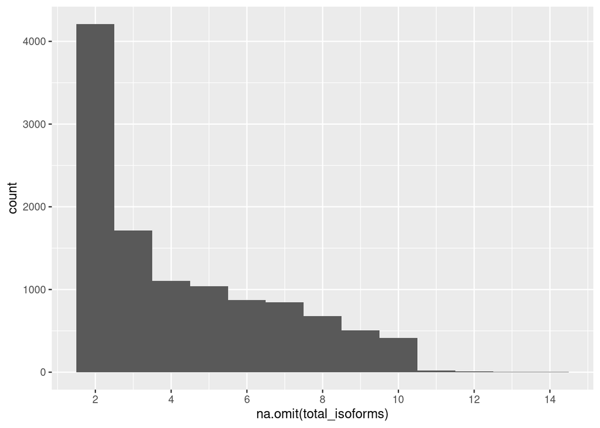

```r
ggplot(em,aes(na.omit(total_isoforms)))+geom_histogram(binwidth=1)+scale_x_continuous(breaks = scales::pretty_breaks(n = 10))
```

### Number of exons in T3 0.5 clusters

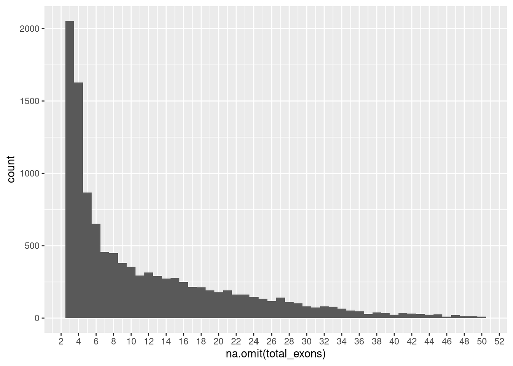

```r
ggplot(em,aes(na.omit(total_exons)))+geom_histogram(binwidth=1)+scale_x_continuous(breaks = scales::pretty_breaks(n = 25))
```

```r
strmin<-function(x){
  if(is.na(x)){return(NA)}
  if(x=='NA,NA'){return(NA)}
  return(min(as.numeric((str_split(x,',',simplify = TRUE)))))
}

em %>% dplyr::filter(total_isoforms<=3,total_exons<=4) %>% arrange(p_value) %>% head(n=10) -> simple_events
```

```r
knitr::kable(em %>% dplyr::filter(test_statistic==max(em$test_statistic,na.rm = TRUE)))
```

| ASM_name | total_isoforms | total_exons | total_read_count_group_1 | total_read_count_group_2 | p_value | test_statistic | psi_values_g1 | psi_values_g2 | isoform_inclusion_group_1 | isoform_inclusion_group_2 | isoform_inclusion_constrained | variance_group_1 | variance_group_2 | variance_constrained | dirichlet_parameter_group_1 | dirichlet_parameter_group_2 | dirichlet_parameter_constrained | paired_isoform_pvalues | isoform_index | merge_info |
| --- | --- | --- | --- | --- | --- | --- | --- | --- | --- | --- | --- | --- | --- | --- | --- | --- | --- | --- | --- | --- |
| ASM#6705 | 8 | 18 | 1725090 | 3221630 | 0 | 17790.88 | 0.0038,0.9961,0,0,0,0,0,1e-04,0.0038,0.9961,0,0,0,0,0,1e-04,0,0,0,0,0,0,0,0,0,0,0,0,0,0,0,0 | 0,0.9953,0,0,0,8e-04,0,0.0039,0,0.9927,0.007,0,0,2e-04,0,0,0,0.9953,0,0,0,8e-04,0,0.0039,0,0.0071,0,0,0,0,0,0 | 0.135669641183081,0.302735644259184,0.0832690951279529,0.0977013302876051,0.067159226646185,0.0901869759339135,0.101262733926016,0.122015352636062 | 0.0271629663533851,0.576223027119766,0.0903908734527616,0.0353663355756934,0.0445877107211876,0.117380108857926,0.0574426339134952,0.0514463440057846 | 0.0632928581097205,0.435829160949948,0.0857258162521782,0.0374495920880231,0.0623480153092689,0.0844353328717026,0.0993462731266946,0.131572951292464 | 0.107511433490385,0.193532198988152,0.0699870884152512,0.0808244955598201,0.0574388075834186,0.0752295013181828,0.0834400598921708,0.0982185706961467 | 0.0229588384568739,0.212158573090802,0.071435158716033,0.0296404709231112,0.037011664761315,0.090012088892896,0.0470408064950976,0.0423983583753194 | 0.0533362392248106,0.221202876747529,0.0705101984249877,0.0324290648354202,0.0525930262946608,0.0695467909084999,0.0804958111523686,0.102793063479999 | 0.0123060808444886,0.0274600071193116,0.00755302518349838,0.00886211873672508,0.00609175984659678,0.00818052002853747,0.00918516021241527,0.0110675518908604 | 0.00410103594010582,0.0869975433828212,0.0136471185018839,0.00533957195170942,0.00673180542123833,0.0177219247271165,0.00867262813305468,0.00776731462278151 | 0.00706147593886604,0.0486247141528845,0.00956428271504204,0.00417818694474961,0.00695606144344487,0.00942030569120568,0.0110838937954743,0.014679369165897 | 0.14556,0.53681,0.2363,0.09367,0.16091,0.21041,0.23239,0.28576 | 1,2,3,4,5,6,7,8 | NA |

```r
em %>% dplyr::filter(test_statistic==max(em$test_statistic,na.rm = TRUE)) %>% pull(ASM_name) %>% as.character() -> top_hit
str_replace(top_hit,'#','') -> top_hit_nohash
gene %>% dplyr::filter(asm==top_hit_nohash)
```

| asm | hugo | ensg |
| --- | --- | --- |
| ASM6705 | GAPDH | ENSG00000111640 |

```r
coords<-coor[which(em$ASM_name==top_hit),]
```

### Find conjoined genes

```r
library(TxDb.Hsapiens.UCSC.hg38.knownGene)
txdb<-TxDb.Hsapiens.UCSC.hg38.knownGene
genes_gr <- genes(txdb)
```

```
##   1613 genes were dropped because they have exons located on both strands
##   of the same reference sequence or on more than one reference sequence,
##   so cannot be represented by a single genomic range.
##   Use 'single.strand.genes.only=FALSE' to get all the genes in a
##   GRangesList object, or use suppressMessages() to suppress this message.
```

```r
#don't want overlapping genes
reduce(genes_gr) -> genes_reduced
ir<-IRanges(start=coor$start,end = coor$end)
coor_gr<-GRanges(seqnames = coor$chr,ranges=ir,strand = coor$strand)
GenomicRanges::findOverlaps(subject=genes_reduced,query=coor_gr) -> hits

#this is my apporac to find clusters that span more than one gene
as.data.frame(hits) %>% group_by(queryHits) %>% summarize(nhit=n()) %>% dplyr::filter(nhit>1) %>% pull(queryHits) -> cg

#now with the subset of ranges that span more than one gene hit up teh original txdb so we can get real gene ids
cg_gr<-coor_gr[cg,]
GenomicRanges::findOverlaps(subject=genes_gr,query=cg_gr) -> cg_hits

cgranges<-genes_gr[subjectHits(cg_hits),"gene_id"]
```

#get teh gene ids

```r
txtable = biomaRt::select(txdb, keys=cgranges$gene_id, columns=columns(txdb), keytype="GENEID")
library(org.Hs.eg.db)
hgnc_names<-biomaRt::select(org.Hs.eg.db, cgranges$gene_id, "SYMBOL")
cgranges$hgnc<-hgnc_names$SYMBOL
knitr::kable(cgranges)
```

| seqnames | start | end | width | strand | gene_id | hgnc |
| --- | --- | --- | --- | --- | --- | --- |
| chr3 | 9933822 | 9945413 | 11592 | + | 78987 | CRELD1 |
| chr3 | 9917074 | 9933630 | 16557 | + | 84818 | IL17RC |
| chr6 | 41789896 | 41895361 | 105466 | - | 25862 | USP49 |
| chr6 | 41905354 | 41921139 | 15786 | - | 9477 | MED20 |
| chr6 | 85607785 | 85643792 | 36008 | - | 10492 | SYNCRIP |
| chr6 | 85676637 | 85678748 | 2112 | - | 26799 | SNORD50A |
| chr6 | 85650491 | 85678932 | 28442 | - | 387066 | SNHG5 |
| chr6 | 85505496 | 85615234 | 109739 | - | 57231 | SNX14 |
| chr6 | 85677589 | 85677658 | 70 | - | 692088 | SNORD50B |
| chr7 | 27106184 | 27140225 | 34042 | - | 3200 | HOXA3 |
| chr7 | 27128507 | 27130780 | 2274 | - | 3201 | HOXA4 |
| chr7 | 27141052 | 27143681 | 2630 | - | 3202 | HOXA5 |
| chr7 | 27145396 | 27150603 | 5208 | - | 3203 | HOXA6 |
| chr7 | 141764097 | 141765197 | 1101 | + | 50831 | TAS2R3 |
| chr7 | 141778442 | 141780819 | 2378 | + | 50832 | TAS2R4 |
| chr8 | 1801125 | 1801192 | 68 | + | 100500912 | MIR3674 |
| chr8 | 1817231 | 1817307 | 77 | + | 693181 | MIR596 |
| chr12 | 49002274 | 49018807 | 16534 | - | 5571 | PRKAG1 |
| chr12 | 49018975 | 49059774 | 40800 | - | 8085 | KMT2D |
| chr13 | 27255064 | 27255135 | 72 | + | 26771 | SNORD102 |
| chr13 | 27255401 | 27255526 | 126 | + | 619499 | SNORA27 |
| chr15 | 50354959 | 50356034 | 1076 | + | 100129387 | GABPB1-AS1 |
| chr15 | 50360329 | 50360410 | 82 | + | 100616396 | MIR4712 |
| chrX | 45746157 | 45746266 | 110 | - | 407006 | MIR221 |
| chrX | 45747015 | 45747124 | 110 | - | 407007 | MIR222 |

#### Top hit: ASM#6705

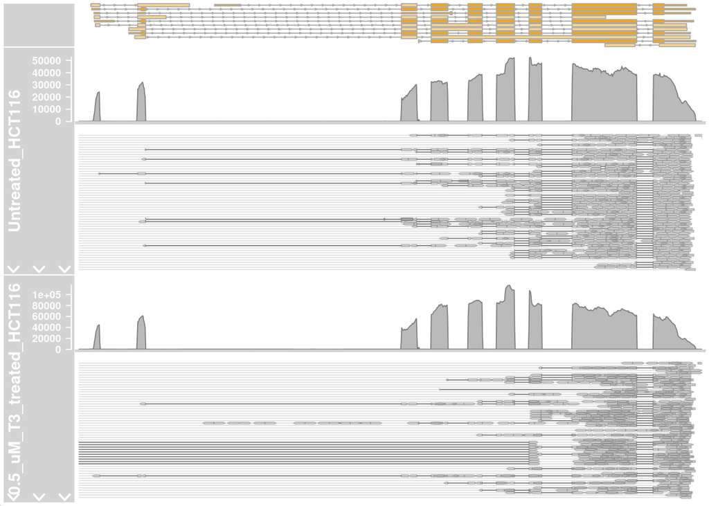

```r
dose="0.5"
#treated
metadata %>% dplyr::filter(str_detect(SampleName,dose)) %>% dplyr::filter(str_detect(SampleName,'T3')) %>% dplyr::filter(Platform=='ILLUMINA') %>% filter(str_detect(SampleName,'HCT116'))  %>% dplyr::pull(Run) -> treated
metadata %>% dplyr::filter(str_detect(SampleName,'Untreated')) %>% dplyr::filter(Platform=='ILLUMINA') %>% dplyr::filter(str_detect(SampleName,'HCT116')) %>% dplyr::pull(Run) -> untreated

#aws s3 cp s3://clk-splicing/SRP091981/SRR5009487.Aligned.sortedByCoord.out.bam SRP091981/
atreated<-"SRR5009487"
auntreated<-"SRR5009474"

plot_window<-function(asm,type){
  stringr::str_replace(asm,'#','') -> asm_nohash
  gene %>% dplyr::filter(asm==asm_nohash)
  coords<-coor[which(em$ASM_name==asm),]
  afrom <- coords$start - 100
  ato <- coords$end + 100
  chr <- as.character(coords$chr)
  treatedName <- metadata %>% dplyr::filter(Run==atreated) %>% pull(SampleName) %>% as.character() %>% stringr::str_replace_all(' ','_')
  untreatedName <- metadata %>% dplyr::filter(Run==auntreated) %>% pull(SampleName) %>% as.character() %>% stringr::str_replace_all(' ','_')
  if(type=='gviz'){
    treatedTrack <- AlignmentsTrack(paste0("./SRP091981/",atreated,".Aligned.sortedByCoord.out.md.bam"), isPaired = TRUE,name = treatedName)
    untreatedTrack  <- AlignmentsTrack(paste0("./SRP091981/",auntreated,".Aligned.sortedByCoord.out.md.bam"), isPaired = TRUE, name = untreatedName)
    options(ucscChromosomeNames=TRUE)

    bmt <- BiomartGeneRegionTrack(genome = "hg38", name="ENSEMBL", chromosome = chr, start = afrom, end = ato,biomart=biomaRt::useMart(biomart="ensembl",dataset="hsapiens_gene_ensembl") , stacking = "squish")
    plotTracks(list(bmt,untreatedTrack,treatedTrack), from = afrom, to = ato, chromosome = chr) #, type = c("coverage","sashimi"))
  }else{
    sashimiPlot<-paste0("rmats2sashimiplot --b1 ",paste0("./SRP091981/",atreated,".Aligned.sortedByCoord.out.md.bam")," --b2 ",paste0("../SRP091981/",auntreated,".Aligned.sortedByCoord.out.md.bam")," -c ",chr,":",coords$strand,":",afrom,":",ato,":../GRCh38_star/gencode.v28.annotation.gtf --l1 ",treatedName," --l2 ",untreatedName, " --exon_s 1 --intron_s 5 -o sashimiout")
    cat(sashimiPlot)
  }
}

plot_window(top_hit,"gviz")
```